# Milestone 4: Infectious Disease Outbreak in California

Nilson Palma, Michelle Zhen Huang

2025-12-05

# Introduction

## Scenario 1: Infectious Disease Outbreak (Simulated) in California

The `sim_novelid_CA.csv` file and `sim_novelid_LACounty.csv` file together represent simulated morbidity for the entire state of California. This analysis combines and analyzes these datasets to understand the temporal and demographic patterns of the outbreak.

### Objectives

This milestone focuses on:

- Final datasets for creation of visualization
- Analyzing outbreak patterns over time by demographic strata
- Identifying populations at highest risk

# Data Preparation

## Load and Clean Morbidity Data

```r
# Load datasets
ca_pop <- read_csv(here("outbreak_data", "ca_pop_2023.csv"))
sim_novelid_ca <- read_csv(here("outbreak_data", "sim_novelid_CA.csv"))
sim_novelid_la <- read_csv(here("outbreak_data", "sim_novelid_LACounty.csv"))

# Clean column names to snakecase
sim_novelid_ca <- sim_novelid_ca %>% clean_names()
sim_novelid_la <- sim_novelid_la %>% clean_names()
```

## Standardize Column Names and Select Variables

```r
# Standardize CA dataset
simca1 <- sim_novelid_ca %>%
  select(
    county,
    age_cat,
    sex,
    race_eth = race_ethnicity,
    dt_diagnosis,
    time_int,
    new_infections,
    cumulative_infected,
    new_severe,
    cumulative_severe
  )

# Standardize LA County dataset
simla1 <- sim_novelid_la %>%
  mutate(county = "Los Angeles") %>%
  select(
    county,
    age_cat = age_category,
    sex,
    race_eth,
    dt_diagnosis = dt_dx,
    new_infections = dx_new,
    cumulative_infected = infected_cumulative,
    new_severe = severe_new,
    cumulative_severe = severe_cumulative
  )
```

## Handle Missing Data

```r
# Remove rows with missing values to ensure clean joins
simca1 <- simca1 %>% drop_na()
simla1 <- simla1 %>% drop_na()
```

## Dates and CDC Week

CDC epidemiological weeks start on Sunday and are the standard for disease surveillance reporting.

```r
# Fix date format for LA County
simla1 <- simla1 %>%
  mutate(dt_diagnosis = dmy(dt_diagnosis))

# CDC has a Sunday start date
set_week_start(7)

# Create CDC week for CA dataset from time_int variable
simca2 <- simca1 %>%
  mutate(
    year = substr(time_int, 1, 4),
    week = substr(time_int, 5, 6),
    cdc_week = aweek::get_date(week = week, year = year)
  ) %>%
  select(-year, -week)

# Create CDC week for LA County from diagnosis date
simla2 <- simla1 %>%
  mutate(
    cdc_week = get_date(
      week = isoweek(dt_diagnosis),
      year = year(dt_diagnosis)
    )
  )
```

## Recode Race/Ethnicity Categories

```r
# Convert numeric race codes to descriptive labels for CA data
simca3 <- simca2 %>%
  mutate(
    race_eth = recode_factor(race_eth,
                             `1` = "White, Non-Hispanic",
                             `2` = "Black, Non-Hispanic",
                             `3` = "American Indian or Alaska Native, Non-Hispanic",
                             `4` = "Asian, Non-Hispanic",
                             `5` = "Native Hawaiian or Pacific Islander, Non-Hispanic",
                             `6` = "Multiracial (two or more of above races), Non-Hispanic",
                             `7` = "Hispanic (any race)",
                             `9` = "Unknown"
    )
  ) %>%
  select(-time_int)

# Ensure race is factor type for LA data
simla3 <- simla2 %>%
  mutate(race_eth = factor(race_eth))
```

## Combine Datasets

```r
# Merge CA and LA County morbidity data
sim_all <- bind_rows(simca3, simla3)
```

# Population Data Preparation

## Clean and Standardize Population Data

```r
# Select and rename columns to match morbidity data
ca_pop1 <- ca_pop %>%
  select(
    county,
    age_cat,
    sex,
    race_eth = race7,
    pop
  )

# Standardize race/ethnicity labels to match morbidity data
ca_pop2 <- ca_pop1 %>%
  mutate(
    race_eth = recode_factor(race_eth,
                             "WhiteTE NH" = "White, Non-Hispanic",
                             "Black NH" = "Black, Non-Hispanic",
                             "AIAN NH" = "American Indian or Alaska Native, Non-Hispanic",
                             "Asian NH" = "Asian, Non-Hispanic",
                             "NHPI NH" = "Native Hawaiian or Pacific Islander, Non-Hispanic",
                             "MR NH" = "Multiracial (two or more of above races), Non-Hispanic",
                             "Hispanic" = "Hispanic (any race)"
    )
  )

# Reclassify age categories to match morbidity data (e.g., 0-17 instead of 0-4, 5-11, 12-17)
ca_pop3 <- ca_pop2 %>%
  mutate(age_cat = case_when(
    age_cat %in% c("0-4", "5-11", "12-17") ~ "0-17",
    TRUE ~ age_cat
  )) %>%
  group_by(county, age_cat, sex, race_eth) %>%
  summarise(pop = sum(pop, na.rm = TRUE)) %>%
  ungroup()
```

## Standardize County Names

```r
# Remove "County" suffix from morbidity data to match population data
sim_all1 <- sim_all %>%
  mutate(
    county = str_to_title(str_remove(county, " County$")),
    county = str_trim(county)
  )

# Ensure consistent formatting in population data
ca_pop4 <- ca_pop3 %>%
  mutate(
    county = str_to_title(str_trim(county))
  )
```

## Join Morbidity and Population Data

```r
# Left join to add population data to morbidity data
sim_pop <- sim_all1 %>%
  left_join(ca_pop4,
            by = c("county", "age_cat", "sex", "race_eth"))
```

# Time Series Analysis

## Calculate Weekly Rates

```r
# Create dataset with weekly cumulative incidence rates and drop columns
fun1 <- sim_pop %>%
  mutate(
    ci_per100k = (new_infections / pop) * 100000,
    severe_per100k = (new_severe / pop) * 100000
  ) %>%
  select(-c(dt_diagnosis, cumulative_infected, cumulative_severe))
```

## Overall California Outbreak Trajectory

```r
# Aggregate to state level by week
ca_overall <- fun1 %>%
  group_by(cdc_week) %>%
  summarise(
    total_cases = sum(new_infections, na.rm = TRUE),
    total_pop = sum(pop, na.rm = TRUE),
    total_severe = sum(new_severe, na.rm = TRUE)
  ) %>%
  mutate(
    ci_per100k = (total_cases / total_pop) * 100000
  ) %>%
  ungroup()
```

## Stratify by Age Group

```r
# Aggregate by age group and week
ca_by_age <- fun1 %>%
  group_by(cdc_week, age_cat) %>%
  summarise(
    total_cases = sum(new_infections, na.rm = TRUE),
    total_pop = sum(pop, na.rm = TRUE),
    total_severe = sum(new_severe, na.rm = TRUE)
  ) %>%
  mutate(
    ci_per100k = (total_cases / total_pop) * 100000
  ) %>%
  ungroup()
```

## Stratify by Race/Ethnicity

```r
# Aggregate by race/ethnicity and week
ca_by_race <- fun1 %>%
  group_by(cdc_week, race_eth) %>%
  summarise(
    total_cases = sum(new_infections, na.rm = TRUE),
    total_pop = sum(pop, na.rm = TRUE),
    total_severe = sum(new_severe, na.rm = TRUE)
  ) %>%
  mutate(
    ci_per100k = (total_cases / total_pop) * 100000
  ) %>%
  ungroup()
```

# Results

## Epidemic Curve by Age Group

The outbreak affected all age groups, with clear differences in disease burden by age.

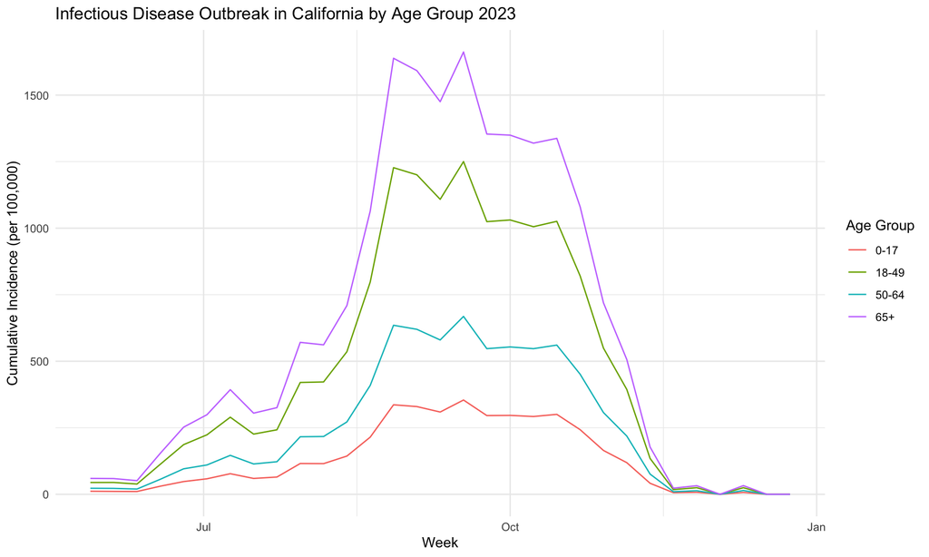

```r
ggplot(ca_by_age, aes(x = cdc_week,
                      y = ci_per100k,
                      color = age_cat)) +
  geom_line() +
  labs(
    title = "Infectious Disease Outbreak in California by Age Group 2023",
    x = "Week",
    y = "Cumulative Incidence (per 100,000)",
    color = "Age Group"
  ) +
  theme_minimal()
```

**Key Findings:**

- All age groups peaked simultaneously around August-September 2023.
- Incidence increases with age, however, cumulative incidence for 18-49 > 50-64.
- Persons aged 65+ experienced the highest burden (~1,600 per 100,000 at peak).
- Persons aged 0-17 had the lowest incidence (~350 per 100,000 at peak).

## Epidemic Curve by Race/Ethnicity

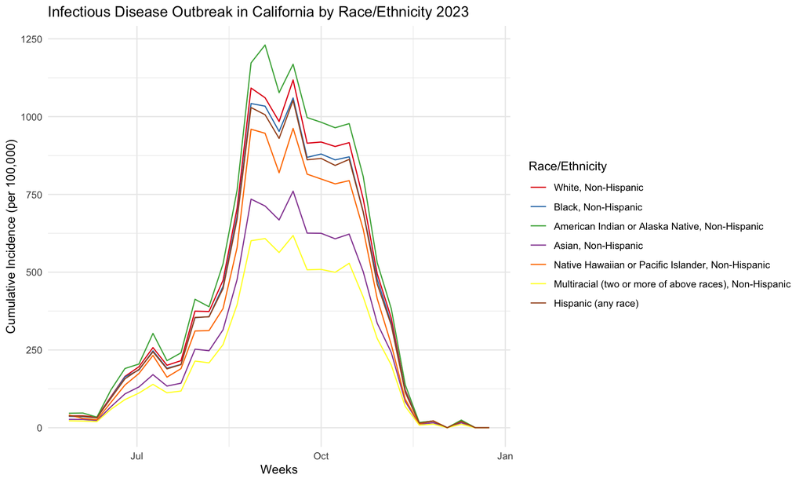

```r
ggplot(ca_by_race, aes(x = cdc_week,
                       y = ci_per100k,
                       color = race_eth)) +
  geom_line() +
  scale_color_brewer(palette = "Set1") +
  labs(
    title = "Infectious Disease Outbreak in California by Race/Ethnicity 2023",
    x = "Weeks",
    y = "Cumulative Incidence (per 100,000)",
    color = "Race/Ethnicity"
  ) +
  theme_minimal()
```

**Key Findings:**

- American Indian or Alaska Native (Non-Hispanic) populations experienced the highest peak incidence (~1,250 per 100,000).
- All racial/ethnic groups followed similar temporal patterns, peaking around the same time.

# Summary Statistics

## Summary by Age Group

```r
summary_age <- ca_by_age %>%
  group_by(age_cat) %>%
  summarise(
    total_cases = sum(total_cases, na.rm = TRUE),
    avg_population = mean(total_pop, na.rm = TRUE), # Total population is the same every week
    peak_weekly_ci = max(ci_per100k, na.rm = TRUE),
    total_severe = sum(total_severe, na.rm = TRUE)
  ) %>%
  mutate(
    attack_rate_percent = (total_cases / avg_population) * 100,
    severe_rate_percent = (total_severe / total_cases) * 100
  )

kable(summary_age,
      digits = 2,
      col.names = c("Age Group", "Total Cases", "Average Population",
                    "Peak Weekly CI (per 100k)", "Total Severe Cases",
                    "Attack Rate (%)", "Severe Rate (%)"),
      caption = "Outbreak Summary Statistics by Age Group") %>%
  kable_styling(bootstrap_options = c("striped", "hover", "condensed"),
                full_width = FALSE)
```

Outbreak Summary Statistics by Age Group

| Age Group | Total Cases | Average Population | Peak Weekly CI (per 100k) | Total Severe Cases | Attack Rate (%) | Severe Rate (%) |
| --- | --- | --- | --- | --- | --- | --- |
| 0-17 | 353210 | 8694111 | 354.22 | 363 | 4.06 | 0.10 |
| 18-49 | 2467284 | 17106505 | 1250.22 | 29325 | 14.42 | 1.19 |
| 50-64 | 540481 | 7086797 | 668.40 | 2822 | 7.63 | 0.52 |
| 65+ | 1188608 | 6221657 | 1662.00 | 94416 | 19.10 | 7.94 |

## Summary by Race/Ethnicity

```r
summary_race <- ca_by_race %>%
  group_by(race_eth) %>%
  summarise(
    total_cases = sum(total_cases, na.rm = TRUE),
    avg_population = mean(total_pop, na.rm = TRUE),
    peak_weekly_ci = max(ci_per100k, na.rm = TRUE),
    total_severe = sum(total_severe, na.rm = TRUE)
  ) %>%
  mutate(
    attack_rate_percent = (total_cases / avg_population) * 100,
    severe_rate_percent = (total_severe / total_cases) * 100
  ) %>%
  arrange(desc(attack_rate_percent))

kable(summary_race,
      digits = 2,
      col.names = c("Race/Ethnicity", "Total Cases", "Average Population",
                    "Peak Weekly CI (per 100k)", "Total Severe Cases",
                    "Attack Rate (%)", "Severe Rate (%)"),
      caption = "Outbreak Summary Statistics by Race/Ethnicity") %>%
  kable_styling(bootstrap_options = c("striped", "hover", "condensed"),
                full_width = FALSE)
```

Outbreak Summary Statistics by Race/Ethnicity

| Race/Ethnicity | Total Cases | Average Population | Peak Weekly CI (per 100k) | Total Severe Cases | Attack Rate (%) | Severe Rate (%) |
| --- | --- | --- | --- | --- | --- | --- |
| American Indian or Alaska Native, Non-Hispanic | 22195 | 158672 | 1230.21 | 671 | 13.99 | 3.02 |
| White, Non-Hispanic | 1778774 | 13848282 | 1117.81 | 63448 | 12.84 | 3.57 |
| Black, Non-Hispanic | 271836 | 2211518 | 1060.00 | 7118 | 12.29 | 2.62 |
| Hispanic (any race) | 1796696 | 14829946 | 1052.14 | 36484 | 12.12 | 2.03 |
| Native Hawaiian or Pacific Islander, Non-Hispanic | 16921 | 153729 | 962.08 | 410 | 11.01 | 2.42 |
| Asian, Non-Hispanic | 546770 | 6295420 | 760.47 | 16568 | 8.69 | 3.03 |
| Multiracial (two or more of above races), Non-Hispanic | 116391 | 1611503 | 617.87 | 2227 | 7.22 | 1.91 |

# Data Dictionary

## Clean Dataset Variables

The final analytical dataset (`fun1`) contains the following key variables:

| Variable | Data Type | Description |
| --- | --- | --- |
| county | Character | California counties |
| age_cat | Character | Age category: 0-17, 18-49, 50-64, 65+ |
| sex | Character | Sex: FEMALE, MALE |
| race_eth | Factor | Race/ethnicity category defined by California Department of Finance |
| new_infections | Numeric | Number of newly diagnosed individuals during the week |
| new_severe | Numeric | Newly identified individuals with severe disease requiring hospitalization |
| cdc_week | Date | Start date of CDC epidemiological week (Sunday) |
| pop | Numeric | CA Dept of Finance population estimates |
| ci_per100k | Numeric | Weekly cumulative incidence rate per 100,000 persons |
| severe_per100k | Numeric | Weekly severe disease rate per 100,000 persons |